# ExactVaRTest-intro

```r
library(ExactVaRTest)
```

# Algorithm

## Test statistic

Let $\{X_t\}_{t=1}^n$ be the $0/1$ hit sequence.  
Under the null $H_0 : X_t \stackrel{\text{i.i.d.}}{\sim} \mathrm{Bernoulli}(\alpha)$,  
define the cell counts

$$T_{00}=\sum_{t=2}^{n}\! \mathbf 1\{X_{t-1}=0,\;X_t=0\},\qquad
T_{01},\;T_{10},\;T_{11}\hspace{2pt}\text{analogously},\qquad
T_0=T_{00}+T_{10},\;T_1=T_{01}+T_{11}.$$

The likelihood-ratio statistic for independence is

$$\mathrm{LR}_{\text{ind}}
= -2\!\left[
T_0\log(1-\hat p)+T_1\log\hat p
\;-\;
T_{00}\log(1-\pi_{01})-T_{01}\log\pi_{01}
\;-\;
T_{10}\log(1-\pi_{11})-T_{11}\log\pi_{11}
\right],$$

where $\displaystyle \hat p = \frac{T_1}{n-1},\qquad \pi_{01} = \frac{T_{01}}{T_{00}+T_{01}},\qquad \pi_{11} = \frac{T_{11}}{T_{10}+T_{11}}.$

**Note.**  
All logarithms are evaluated with the safe function

$$\operatorname{safe\_log}(x)=\log\bigl(\max\{x,10^{-15}\}\bigr),$$

which prevents floating-point underflow when $x$ is extremely small.

## State representation

At time $k\;(1\le k\le n)$ we compress every partial path into the state

$$s = \bigl(\,\ell,\;c_{00},c_{10},c_{01},c_{11}\bigr),\qquad
\ell\in\{0,1\},$$

where $\ell$ is the last hit and $c_{xy}$ are the running counts of  
$(X_{t-1}=x,\;X_t=y)$ up to time $k$.  
The forward probability attached to $s$ is the summed mass of *all* paths that lead to this state.

## One-step recursion

With transition probabilities

$$P(X_k=0\mid H_0)=1-\alpha,\qquad
P(X_k=1\mid H_0)=\alpha,$$

each state produces two offspring:

$$\begin{aligned}
\textbf{0-step}:&\;
(\ell,c_{00},c_{10},c_{01},c_{11};\,p)
\;\longrightarrow\;
(0,c_{00}\!+\!\mathbf1_{\{\ell=0\}},c_{10}\!+\!\mathbf1_{\{\ell=1\}},
c_{01},c_{11};\,p(1-\alpha)),\\[6pt]
\textbf{1-step}:&\;
(\ell,c_{00},c_{10},c_{01},c_{11};\,p)
\;\longrightarrow\;
(1,c_{00},c_{10},
c_{01}\!+\!\mathbf1_{\{\ell=0\}},c_{11}\!+\!\mathbf1_{\{\ell=1\}};\,p\alpha).
\end{aligned}$$

If multiple paths arrive at the **same** offspring state, their probabilities are summed (*state aggregation*).

## Pruning

States with probability mass below a fixed threshold $\tau\;(=10^{-15}\text{ by default})$ are discarded at each step:

$$\text{keep } s \iff p_s \ge \tau.$$

Empirically this leaves the exact distribution unchanged while reducing the state space by several orders of magnitude.

## Conditional-coverage statistic $\mathrm{LR}_{\text{cc}}$

Christoffersen’s conditional-coverage test adds an unconditional-coverage term

$$\mathrm{LR}_{\text{uc}}
= -2\!\Bigl[
c_1\log\alpha + (n-c_1)\log(1-\alpha)
-c_1\log\hat\alpha - (n-c_1)\log(1-\hat\alpha)
\Bigr],
\qquad
\hat\alpha=\frac{c_1}{n},$$

to the independence part, so that

$$\mathrm{LR}_{\text{cc}}
= \mathrm{LR}_{\text{uc}} + \mathrm{LR}_{\text{ind}}.$$

To adapt the algorithm, we augment each state with the running total of exceptions $c_1=\sum_{t=1}^{k} X_t$:

$$s = (\ell,\,c_1,\,c_{00},c_{10},c_{01},c_{11}).$$

A 1-step transition increments $c_1$; a 0-step leaves it unchanged. All other mechanics (expansion, aggregation, pruning) are identical to the independence algorithm.  
At termination we compute $\mathrm{LR}_{\text{uc}}$ and $\mathrm{LR}_{\text{ind}}$ for every state, sum them to obtain $\mathrm{LR}_{\text{cc}}$, and aggregate identical values as before.

# Performance

The table below benchmarks how long the package needs to produce the exact finite-sample distribution for a range of $n$ and $\alpha$.

```r
library(bench)
library(dplyr)
library(tidyr)
library(purrr)
library(knitr)

n_vec     <- c(50, 100, 250, 500, 750, 1000)
alpha_vec <- c(0.01, 0.025, 0.05)

grid <- expand.grid(n = n_vec, alpha = alpha_vec, KEEP.OUT.ATTRS = FALSE)

bench_one <- function(n, alpha, fun) {
  bm <- bench::mark(
    fun(n = n, alpha = alpha),
    iterations = 3,
    check = FALSE
  )
  tibble(
    n        = n,
    alpha    = alpha,
    median_s = as.numeric(bm$median)
  )
}

timings_ind <- pmap_dfr(grid, bench_one, fun = lr_ind_dist)

timings_cc  <- pmap_dfr(grid, bench_one, fun = lr_cc_dist)

fmt_wide <- function(df) {
  df %>%
    mutate(alpha = sprintf("alpha = %.3f", alpha)) %>%
    pivot_wider(names_from = alpha, values_from = median_s) %>%
    arrange(n)
}

table_ind <- fmt_wide(timings_ind)
table_cc  <- fmt_wide(timings_cc)

kable(
  table_ind,
  digits = 3,
  col.names = c("n", "α = 0.010", "α = 0.025", "α = 0.050"),
  caption   = "Median run-time (seconds) for lr_ind_dist()"
)
```

Median run-time (seconds) for lr_ind_dist()

| n | α = 0.010 | α = 0.025 | α = 0.050 |
| --- | --- | --- | --- |
| 50 | 0.005 | 0.009 | 0.014 |
| 100 | 0.015 | 0.026 | 0.044 |
| 250 | 0.055 | 0.120 | 0.214 |
| 500 | 0.155 | 0.352 | 0.752 |
| 750 | 0.288 | 0.710 | 1.543 |
| 1000 | 0.468 | 1.130 | 2.599 |

```r
kable(
  table_cc,
  digits = 3,
  col.names = c("n", "α = 0.010", "α = 0.025", "α = 0.050"),
  caption   = "Median run-time (seconds) for lr_cc_dist()"
)
```

Median run-time (seconds) for lr_cc_dist()

| n | α = 0.010 | α = 0.025 | α = 0.050 |
| --- | --- | --- | --- |
| 50 | 0.005 | 0.008 | 0.013 |
| 100 | 0.014 | 0.025 | 0.044 |
| 250 | 0.052 | 0.106 | 0.210 |
| 500 | 0.151 | 0.335 | 0.725 |
| 750 | 0.277 | 0.660 | 1.527 |
| 1000 | 0.435 | 1.097 | 2.651 |

```r
library(xts)

alpha  <- 0.01
window <- 250

local_file <- "inst/extdata/GSPC_close.rds"
file_path  <- if (file.exists(local_file)) local_file else
              system.file("extdata", "GSPC_close.rds", package = "ExactVaRTest")

px  <- readRDS(file_path)
ret <- diff(log(px), lag = 1)

VaR <- rollapply(
  ret, window,
  function(r) quantile(r, alpha, na.rm = TRUE),
  by.column = FALSE, align = "right"
)

keep <- complete.cases(ret, VaR)
ret  <- ret[keep]
VaR  <- coredata(VaR[keep])

x <- ifelse(coredata(ret) < VaR, 1L, 0L)

cat("Series length :", length(x), "\n")
```

```
#> Series length : 2399
```

```r
cat("Exception rate:", mean(x), "\n\n")
```

```
#> Exception rate: 0.01542309
```

```r
bench_res <- bench::mark(
  LR_ind = backtest_lr(x, alpha, "ind"),
  LR_cc  = backtest_lr(x, alpha, "cc"),
  iterations = 10,
  check      = FALSE
)

suppressWarnings(
  print(bench_res[, c("expression", "median")])
)
```

```
#> # A tibble: 2 × 2
#>   expression   median
#>   <bch:expr> <bch:tm>
#> 1 LR_ind        2.14s
#> 2 LR_cc         1.98s
```

```r
res_ind <- backtest_lr(x, alpha, "ind")
res_cc  <- backtest_lr(x, alpha, "cc")

cat("\n--- Independence test ---\n")
```

```
#>
#> --- Independence test ---
```

```r
print(res_ind)
```

```
#> Exact finite-sample back-test
#> --------------------------------
#> Test           : Independence (LR_ind)
#> Sample size    : 2399
#> Model alpha    : 0.0100
#> Signif. level  : 0.0500
#> LR statistic   : 13.9736
#> Exact p-value  : 0.0001
#> Decision       : REJECT null at 5.00% level
```

```r
cat("\n--- Conditional-coverage test ---\n")
```

```
#>
#> --- Conditional-coverage test ---
```

```r
print(res_cc)
```

```
#> Exact finite-sample back-test
#> --------------------------------
#> Test           : Conditional coverage (LR_cc)
#> Sample size    : 2399
#> Model alpha    : 0.0100
#> Signif. level  : 0.0500
#> LR statistic   : 20.0878
#> Exact p-value  : 0.0000
#> Decision       : REJECT null at 5.00% level
```

# Distribution comparison

The following figure shows the exact finite-sample CDF with the usual $\chi^2$ approximation for $n$ = 250, $\alpha$ = 1%.

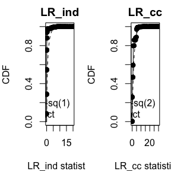

```r
n      <- 250
alpha  <- 0.01

d_ind <- lr_ind_dist(n, alpha)
d_cc <- lr_cc_dist(n, alpha)
d_cc$LR   <- d_cc$LR_cc
d_cc$prob <- d_cc$prob_cc

oldpar <- par(mfrow = c(1, 2), mar = c(4, 4, 2, 1))

# LR_ind vs χ²(1)
curve(pchisq(x, df = 1), 0, 20, lty = 2, ylab = "CDF",
      xlab = "LR_ind statistic", main = "LR_ind")
lines(stepfun(d_ind$LR, c(0, cumsum(d_ind$prob))), pch = 19)
legend("bottomright", c("Chi-sq(1)", "Exact"), lty = c(2, 1), bty = "n")

# LR_cc vs χ²(2)
curve(pchisq(x, df = 2), 0, 30, lty = 2, ylab = "CDF",
      xlab = "LR_cc statistic", main = "LR_cc")
lines(stepfun(d_cc$LR, c(0, cumsum(d_cc$prob))), pch = 19)
legend("bottomright", c("Chi-sq(2)", "Exact"), lty = c(2, 1), bty = "n")
```

```r
par(oldpar)
```

# Size distortion

A quick Monte-Carlo shows how often each method rejects under the null when $n$ = 250 and $\alpha$ = 1%.

```r
n     <- 250
alpha <- 0.01
set.seed(1)

# LR_cc
p.chi.cc <- replicate(
  1000,
  ExactVaRTest::lr_cc_stat(rbinom(n, 1, alpha), alpha) > qchisq(.95, 2)
)
p.exact.cc <- replicate(
  1000,
  {
    x <- rbinom(n, 1, alpha)
    ExactVaRTest::backtest_lr(x, alpha, "cc")$pval < 0.05
  }
)

# LR_ind
p.chi.ind <- replicate(
  1000,
  ExactVaRTest::lr_ind_stat(rbinom(n, 1, alpha), alpha) > qchisq(.95, 1)
)
p.exact.ind <- replicate(
  1000,
  {
    x <- rbinom(n, 1, alpha)
    ExactVaRTest::backtest_lr(x, alpha, "ind")$pval < 0.05
  }
)

data.frame(
  Test = c("LR_cc Chi^2", "LR_cc Exact", "LR_ind Chi^2", "LR_ind Exact"),
  Size = c(mean(p.chi.cc), mean(p.exact.cc), mean(p.chi.ind), mean(p.exact.ind))
)
```

```
#>           Test  Size
#> 1  LR_cc Chi^2 0.009
#> 2  LR_cc Exact 0.032
#> 3 LR_ind Chi^2 0.012
#> 4 LR_ind Exact 0.037
```

# Rolling back-test on real data

We plot 250-day rolling p-values ($\alpha$ = 1%) for LRind and LRcc.

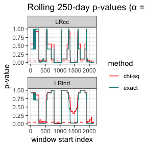

```r
library(ggplot2)
library(dplyr)
library(tidyr)

alpha <- 0.01
win   <- 250

local_file <- "inst/extdata/GSPC_close.rds"
file_path  <- if (file.exists(local_file)) local_file else
              system.file("extdata", "GSPC_close.rds", package = "ExactVaRTest")

px  <- readRDS(file_path)
px  <- px[index(px) >= "2012-01-01"]

ret <- diff(log(px))

VaR <- rollapply(
  ret, win,
  function(r) quantile(r, alpha, na.rm = TRUE),
  by.column = FALSE, align = "right"
)

keep <- complete.cases(ret, VaR)
r  <- coredata(ret[keep])
v  <- coredata(VaR[keep])
exc <- ifelse(r < v, 1L, 0L)

n_seg <- length(exc) - win + 1
ind_exact <- ind_chi <- cc_exact <- cc_chi <- numeric(n_seg)

for (i in seq_len(n_seg)) {
  seg <- exc[i:(i + win - 1)]
  ind_stat <- ExactVaRTest::lr_ind_stat(seg, alpha)
  cc_stat  <- ExactVaRTest::lr_cc_stat(seg, alpha)
  ind_exact[i] <- ExactVaRTest::pval_lr_ind(ind_stat, win, alpha)
  cc_exact[i]  <- ExactVaRTest::pval_lr_cc(cc_stat,  win, alpha)
  ind_chi[i]   <- pchisq(ind_stat, df = 1, lower.tail = FALSE)
  cc_chi[i]    <- pchisq(cc_stat,  df = 2, lower.tail = FALSE)
}

df <- tibble(
  idx = seq_len(n_seg),
  ind_exact, ind_chi, cc_exact, cc_chi
) %>%
  pivot_longer(cols = -idx,
               names_to  = c("test", "method"),
               names_pattern = "(ind|cc)_(.*)",
               values_to = "pval") %>%
  mutate(test = ifelse(test == "ind", "LRind", "LRcc"),
         method = ifelse(method == "exact", "exact", "chi-sq"))

ggplot(df, aes(idx, pval, colour = method)) +
  geom_step() +
  geom_hline(yintercept = 0.05, linetype = 2, colour = "red") +
  facet_wrap(~ test, ncol = 1, scales = "free_x") +
  scale_colour_manual(values = c("chi-sq" = "red", "exact" = "cyan4")) +
  labs(x = "window start index", y = "p-value",
       title = "Rolling 250-day p-values (α = 1%)") +
  theme_bw()
```

# Finite-sample Critical Values Table

```r
library(ExactVaRTest)

n_set      <- c(250, 500, 750, 1000)
alpha_set  <- c(0.005, 0.01, 0.025, 0.05)
gamma_set  <- c(0.90, 0.95, 0.99)

q_lr <- function(d, g) d$LR[which(cumsum(d$prob) >= g)[1L]]

tbl <- expand.grid(n = n_set,
                   alpha = alpha_set,
                   gamma = gamma_set,
                   KEEP.OUT.ATTRS = FALSE,
                   stringsAsFactors = FALSE)

tbl$crit_ind <- mapply(function(n, a, g)
  q_lr(lr_ind_dist(n, a, prune_threshold = 1e-15), g),
  tbl$n, tbl$alpha, tbl$gamma, SIMPLIFY = TRUE)

tbl$crit_cc <- mapply(function(n, a, g) {
  d <- lr_cc_dist(n, a, prune_threshold = 1e-15)
  d$LR   <- d$LR_cc
  d$prob <- d$prob_cc
  q_lr(d, g)
}, tbl$n, tbl$alpha, tbl$gamma, SIMPLIFY = TRUE)

print(tbl, digits = 6)
```

```
#>       n alpha gamma  crit_ind crit_cc
#> 1   250 0.005  0.90 0.0731725 2.50627
#> 2   500 0.005  0.90 0.1012163 5.01254
#> 3   750 0.005  0.90 0.0969055 2.86928
#> 4  1000 0.005  0.90 0.1291639 2.75990
#> 5   250 0.010  0.90 0.2049324 5.02517
#> 6   500 0.010  0.90 0.3306308 3.90104
#> 7   750 0.010  0.90 0.4592630 3.55360
#> 8  1000 0.010  0.90 0.6605875 3.48837
#> 9   250 0.025  0.90 1.2157096 4.04724
#> 10  500 0.025  0.90 1.4290833 3.96582
#> 11  750 0.025  0.90 1.7268626 4.07639
#> 12 1000 0.025  0.90 1.9858767 4.29970
#> 13  250 0.050  0.90 2.1991552 4.17997
#> 14  500 0.050  0.90 2.8597921 4.28064
```

[output cut: 34 more lines]

# Backtesting CoVaR with random P′∼ Binomial(P, α′)

$p = \sum_{k=0}^{P} \Pr\!\bigl(P' = k\bigr)\,\Pr\!\bigl(LR_{\text{uc/ind}} \ge \text{obs}\mid P' = k\bigr)$

```r
library(ExactVaRTest)

set.seed(123)

P            <- 250
alpha        <- 0.05
alpha_prime  <- 0.10

inst_flag <- rbinom(P, 1, alpha_prime)
sys_flag  <- if (sum(inst_flag)) rbinom(sum(inst_flag), 1, alpha) else integer(0)

lr_uc  <- lr_uc_stat(sys_flag,  alpha)
lr_ind <- lr_ind_stat(sys_flag, alpha)

mix_tail <- function(lr_obs, P, alpha, alpha_prime,
                     type = c("uc", "ind"), prune = 1e-15) {
  type <- match.arg(type)
  w    <- dbinom(0:P, P, alpha_prime)

  tail_prob <- function(k) {
    if (type == "uc") {
      if (!k) return(as.numeric(lr_obs <= 0))
      d <- lr_uc_dist(k, alpha)
      sum(d$prob[d$LR >= lr_obs])
    } else {
      if (k < 2) return(as.numeric(lr_obs <= 0))
      d <- lr_ind_dist(k, alpha, prune)
      sum(d$prob[d$LR >= lr_obs])
    }
  }

  sum(vapply(0:P, tail_prob, numeric(1)) * w)
}

p_uc  <- mix_tail(lr_uc,  P, alpha, alpha_prime, "uc")
p_ind <- mix_tail(lr_ind, P, alpha, alpha_prime, "ind")

data.frame(
  test = c("UC", "IND"),
  stat = c(lr_uc, lr_ind),
  p    = c(p_uc, p_ind)
)
```

```
#>   test       stat         p
#> 1   UC 0.03710616 0.8595301
#> 2  IND 0.09094042 0.5100388
```